# About

The following code was demonstrated by Mangesh Narayan during the Week-1 mentor session

## Case study - Uber Data Analysis

The data of a driver’s uber trips are available for year 2016. The manager wants us to explore this data to give him some useful insights about the trip behaviour of the Uber driver.

## About dataset

The dataset contains Start Date, End Date, Start Location, End Location, Miles Driven and Purpose of drive (Business, Personal, Meals, Errands, Meetings, Customer Support etc.)

## Concepts covered:

1. Data profiling
2. `.groupby()` function
3. `.apply()` function
4. DateTime operations

# Libraries

```python
import numpy as np
import pandas as pd
from pandas_profiling import ProfileReport
import matplotlib.pyplot as plt
import seaborn as sns
from datetime import datetime
import calendar
start = pd.Timestamp.now()
```

# Read data

```python
# Firstly lets explore pandas features of reading data from hdd
# Skip first n nows
df = pd.read_csv('../01_InFiles/Uber+Drives+2016.csv', skiprows = 100)
df
# Load only the first n rows
df = pd.read_csv('../01_InFiles/Uber+Drives+2016.csv', nrows = 100)  #
df
# Load only selected columns
df = pd.read_csv('../01_InFiles/Uber+Drives+2016.csv', usecols = ['START_DATE*', 'END_DATE*'])
df
# Finally read data as required
df = pd.read_csv('../01_InFiles/Uber+Drives+2016.csv')
df
```

|  | START_DATE* | END_DATE* | CATEGORY* | START* | STOP* | MILES* | PURPOSE* |
| --- | --- | --- | --- | --- | --- | --- | --- |
| 0 | 1/1/2016 21:11 | 1/1/2016 21:17 | Business | Fort Pierce | Fort Pierce | 5.1 | Meal/Entertain |
| 1 | 1/2/2016 1:25 | 1/2/2016 1:37 | Business | Fort Pierce | Fort Pierce | 5.0 | NaN |
| 2 | 1/2/2016 20:25 | 1/2/2016 20:38 | Business | Fort Pierce | Fort Pierce | 4.8 | Errand/Supplies |
| 3 | 1/5/2016 17:31 | 1/5/2016 17:45 | Business | Fort Pierce | Fort Pierce | 4.7 | Meeting |
| 4 | 1/6/2016 14:42 | 1/6/2016 15:49 | Business | Fort Pierce | West Palm Beach | 63.7 | Customer Visit |
| ... | ... | ... | ... | ... | ... | ... | ... |
| 1151 | 12/31/2016 13:24 | 12/31/2016 13:42 | Business | Kar?chi | Unknown Location | 3.9 | Temporary Site |
| 1152 | 12/31/2016 15:03 | 12/31/2016 15:38 | Business | Unknown Location | Unknown Location | 16.2 | Meeting |
| 1153 | 12/31/2016 21:32 | 12/31/2016 21:50 | Business | Katunayake | Gampaha | 6.4 | Temporary Site |
| 1154 | 12/31/2016 22:08 | 12/31/2016 23:51 | Business | Gampaha | Ilukwatta | 48.2 | Temporary Site |
| 1155 | Totals | NaN | NaN | NaN | NaN | 12204.7 | NaN |

1156 rows × 7 columns

# Beautiful report from Pandas profiling optional

```python
# # Regular report
# profile = ProfileReport(df, title="Pandas Profiling Report")
# profile.to_widgets()  # style 1
# profile.to_notebook_iframe()  # style 2
# # Explorative report
# profile = ProfileReport(df, title="Pandas Profiling Report", explorative=True)
# profile.to_notebook_iframe()
# # Minimal report
# profile = ProfileReport(df, minimal=True)
# # Save if req
# profile.to_file("../02_OutFiles/pandasProfiling.html")
```

# Notes

1. Whether we apply `.to_widgets()` or `.to_notebook_frame()` the profile style is same when saved into an html.

# Rename columns for readability

```python
# Form a new list and modify col names
col_names = ['START_DATE','END_DATE','CAT', 'START' , 'STOP' , 'MILES','PURPOSE']
df.columns = col_names
# OR by using `.replace()` in case of large no. of cols
# df.columns = df.columns.str.replace("*", "")
# OR by renaming specific cols
# df.rename( columns = {'CAT':'CATEGORY'})
df.head()
```

|  | START_DATE | END_DATE | CAT | START | STOP | MILES | PURPOSE |
| --- | --- | --- | --- | --- | --- | --- | --- |
| 0 | 1/1/2016 21:11 | 1/1/2016 21:17 | Business | Fort Pierce | Fort Pierce | 5.1 | Meal/Entertain |
| 1 | 1/2/2016 1:25 | 1/2/2016 1:37 | Business | Fort Pierce | Fort Pierce | 5.0 | NaN |
| 2 | 1/2/2016 20:25 | 1/2/2016 20:38 | Business | Fort Pierce | Fort Pierce | 4.8 | Errand/Supplies |
| 3 | 1/5/2016 17:31 | 1/5/2016 17:45 | Business | Fort Pierce | Fort Pierce | 4.7 | Meeting |
| 4 | 1/6/2016 14:42 | 1/6/2016 15:49 | Business | Fort Pierce | West Palm Beach | 63.7 | Customer Visit |

# Understand data

```python
df.head(8)
df.tail(10)
print(df.shape)
# Overall view
df.info()
df.count()  # same as above, gives non-null number of records
```

```
(1156, 7)
<class 'pandas.core.frame.DataFrame'>
RangeIndex: 1156 entries, 0 to 1155
Data columns (total 7 columns):
 #   Column      Non-Null Count  Dtype
---  ------      --------------  -----
 0   START_DATE  1156 non-null   object
 1   END_DATE    1155 non-null   object
 2   CAT         1155 non-null   object
 3   START       1155 non-null   object
 4   STOP        1155 non-null   object
 5   MILES       1156 non-null   float64
 6   PURPOSE     653 non-null    object
dtypes: float64(1), object(6)
memory usage: 63.3+ KB
```

```
START_DATE    1156
END_DATE      1155
CAT           1155
START         1155
STOP          1155
MILES         1156
PURPOSE        653
dtype: int64
```

# Notes

1. It appears that there are a total of 1156 rows. The columns having 1155 non-null rows have one NaN due the last 'Totals' row.
2. `PURPOSE` column has lots of missing values

# Explore NaNs

```python
# NaNs per column
df.isnull().sum()
# NaNs per column - logical output
df.isnull().any()
# NaNs in entire df - logical output
df.isnull().any().any()
# Get the list of columns having any NaNs
null_cols = df.columns[df.isnull().any()]
list(null_cols)
```

```
['END_DATE', 'CAT', 'START', 'STOP', 'PURPOSE']
```

# Explore `PURPOSE` column

```python
# Entries where PURPOSE is null
df[df['PURPOSE'].isnull()].head()
# Entries where PURPOSE is not null
df[~df['PURPOSE'].isnull()].head()
# Count of non-nulls in this col
df['PURPOSE'].count()
```

```
653
```

# SQL Like queries

SQL like queris can also be made on any col

```python
# Get records with MILES>30
df[df['MILES'] > 30]
df[df.MILES == 30]
df[df.MILES != 30]
# Same query in SQL format
df.query('MILES > 30')
```

|  | START_DATE | END_DATE | CAT | START | STOP | MILES | PURPOSE |
| --- | --- | --- | --- | --- | --- | --- | --- |
| 4 | 1/6/2016 14:42 | 1/6/2016 15:49 | Business | Fort Pierce | West Palm Beach | 63.7 | Customer Visit |
| 36 | 1/20/2016 13:25 | 1/20/2016 14:19 | Business | Raleigh | Cary | 40.2 | Customer Visit |
| 108 | 2/16/2016 3:21 | 2/16/2016 4:13 | Business | Katunayaka | Unknown Location | 43.7 | Customer Visit |
| 232 | 3/17/2016 12:52 | 3/17/2016 15:11 | Business | Austin | Katy | 136.0 | Customer Visit |
| 233 | 3/17/2016 15:16 | 3/17/2016 15:58 | Business | Katy | Houston | 30.2 | Meeting |
| 245 | 3/19/2016 14:01 | 3/19/2016 14:57 | Business | Sugar Land | Houston | 35.1 | Customer Visit |
| 246 | 3/19/2016 15:34 | 3/19/2016 16:38 | Business | Houston | Galveston | 36.5 | Meal/Entertain |
| 251 | 3/19/2016 19:33 | 3/19/2016 20:39 | Business | Galveston | Houston | 57.0 | Customer Visit |
| 268 | 3/25/2016 13:24 | 3/25/2016 16:22 | Business | Cary | Latta | 144.0 | Customer Visit |
| 269 | 3/25/2016 16:52 | 3/25/2016 22:22 | Business | Latta | Jacksonville | 310.3 | Customer Visit |
| 270 | 3/25/2016 22:54 | 3/26/2016 1:39 | Business | Jacksonville | Kissimmee | 201.0 | Meeting |
| 295 | 4/2/2016 12:21 | 4/2/2016 14:47 | Business | Kissimmee | Daytona Beach | 77.3 | Customer Visit |
| 296 | 4/2/2016 16:57 | 4/2/2016 18:09 | Business | Daytona Beach | Jacksonville | 80.5 | Customer Visit |
| 297 | 4/2/2016 19:38 | 4/2/2016 22:36 | Business | Jacksonville | Ridgeland | 174.2 | Customer Visit |
| 298 | 4/2/2016 23:11 | 4/3/2016 1:34 | Business | Ridgeland | Florence | 144.0 | Meeting |
| 299 | 4/3/2016 2:00 | 4/3/2016 4:16 | Business | Florence | Cary | 159.3 | Meeting |
| 335 | 4/28/2016 13:30 | 4/28/2016 13:49 | Business | Raleigh | Cary | 32.8 | Customer Visit |
| 478 | 6/27/2016 7:37 | 6/27/2016 8:48 | Business | New Orleans | Covington | 46.9 | NaN |
| 546 | 7/14/2016 16:39 | 7/14/2016 20:05 | Business | Morrisville | Banner Elk | 195.3 | NaN |
| 554 | 7/16/2016 15:29 | 7/16/2016 16:57 | Personal | Newland | Boone | 41.9 | NaN |
| 559 | 7/17/2016 12:20 | 7/17/2016 15:25 | Personal | Boone | Cary | 180.2 | Commute |
| 651 | 8/11/2016 18:37 | 8/11/2016 19:29 | Business | Cary | Wake Forest | 31.7 | NaN |
| 652 | 8/11/2016 20:59 | 8/11/2016 21:44 | Business | Wake Forest | Cary | 31.9 | NaN |
| 707 | 8/24/2016 13:01 | 8/24/2016 15:25 | Business | Unknown Location | Unknown Location | 96.2 | NaN |
| 708 | 8/25/2016 15:17 | 8/25/2016 16:22 | Business | Unknown Location | Unknown Location | 35.0 | NaN |
| 710 | 8/25/2016 17:19 | 8/25/2016 19:20 | Business | Unknown Location | Unknown Location | 50.4 | NaN |
| 726 | 8/27/2016 14:01 | 8/27/2016 15:44 | Business | Lahore | Unknown Location | 86.6 | NaN |
| 727 | 8/27/2016 16:15 | 8/27/2016 19:13 | Business | Unknown Location | Unknown Location | 156.9 | NaN |
| 751 | 9/6/2016 17:49 | 9/6/2016 17:49 | Business | Unknown Location | Unknown Location | 69.1 | NaN |
| 776 | 9/27/2016 21:01 | 9/28/2016 2:37 | Business | Unknown Location | Unknown Location | 195.6 | NaN |
| 779 | 9/30/2016 17:39 | 9/30/2016 20:20 | Business | Islamabad | Islamabad | 37.7 | NaN |
| 788 | 10/6/2016 17:23 | 10/6/2016 17:40 | Business | R?walpindi | Unknown Location | 112.6 | NaN |
| 791 | 10/7/2016 10:56 | 10/7/2016 10:59 | Business | Unknown Location | Lahore | 33.2 | NaN |
| 841 | 10/20/2016 12:19 | 10/20/2016 13:17 | Business | Berkeley | San Jose | 47.7 | NaN |
| 842 | 10/20/2016 20:44 | 10/20/2016 21:37 | Business | San Jose | Emeryville | 44.6 | NaN |
| 869 | 10/28/2016 15:53 | 10/28/2016 17:59 | Business | Cary | Winston Salem | 107.0 | Meeting |
| 870 | 10/28/2016 18:13 | 10/28/2016 20:07 | Business | Winston Salem | Asheville | 133.6 | Meeting |
| 871 | 10/28/2016 20:13 | 10/28/2016 22:00 | Business | Asheville | Topton | 91.8 | Meeting |
| 872 | 10/29/2016 15:22 | 10/29/2016 17:05 | Business | Topton | Hayesville | 40.7 | Meeting |
| 873 | 10/29/2016 17:13 | 10/29/2016 19:19 | Business | Hayesville | Topton | 75.7 | NaN |
| 880 | 10/30/2016 13:24 | 10/30/2016 14:37 | Business | Bryson City | Asheville | 68.4 | NaN |
| 881 | 10/30/2016 15:22 | 10/30/2016 18:23 | Business | Asheville | Mebane | 195.9 | NaN |
| 882 | 10/30/2016 18:26 | 10/30/2016 19:39 | Business | Mebane | Cary | 45.2 | NaN |
| 913 | 11/6/2016 16:27 | 11/6/2016 17:28 | Business | Santa Clara | Berkeley | 43.9 | Customer Visit |
| 936 | 11/11/2016 9:35 | 11/11/2016 10:23 | Business | Berkeley | Menlo Park | 45.9 | Customer Visit |
| 939 | 11/11/2016 14:39 | 11/11/2016 15:46 | Business | Menlo Park | Berkeley | 36.6 | Customer Visit |
| 960 | 11/14/2016 11:24 | 11/14/2016 12:13 | Business | Berkeley | Mountain View | 44.6 | Customer Visit |
| 961 | 11/14/2016 13:40 | 11/14/2016 14:33 | Business | Mountain View | Berkeley | 43.6 | Customer Visit |
| 979 | 11/20/2016 10:27 | 11/20/2016 11:32 | Business | Cary | Cary | 39.2 | Between Offices |
| 1088 | 12/21/2016 20:56 | 12/21/2016 23:42 | Business | Rawalpindi | Unknown Location | 103.0 | Meeting |
| 1089 | 12/22/2016 15:40 | 12/22/2016 16:38 | Business | Unknown Location | Unknown Location | 32.3 | Meeting |
| 1154 | 12/31/2016 22:08 | 12/31/2016 23:51 | Business | Gampaha | Ilukwatta | 48.2 | Temporary Site |
| 1155 | Totals | NaN | NaN | NaN | NaN | 12204.7 | NaN |

# Explore `MILES` column

```python
# Top ten rows of max and min MILES
df.sort_values(by = 'MILES' , ascending = False).head(10)
df.sort_values(by = 'MILES' , ascending = True).head(10)
# At this point - see Notes
# Remove the row c/t anomalously high MILES value
df[df.MILES ==df.MILES.max()]
df = df[df.MILES < 1000]
```

# Notes

1. On investigating the ten highest and lowest values in `MILES` col, the max `MILES` value looked suspicious going much beyond the range of the rest of the values i.e., 0.5 to 310.3.
2. This led us to the decision of removing the suspicious value.

# Explore numerical cols of df

```python
df.dtypes
df.describe().T
```

|  | count | mean | std | min | 25% | 50% | 75% | max |
| --- | --- | --- | --- | --- | --- | --- | --- | --- |
| MILES | 1155.0 | 10.56684 | 21.579106 | 0.5 | 2.9 | 6.0 | 10.4 | 310.3 |

# Drop rows with null values

```python
df_dropped = df.dropna()
df_dropped.shape
df.shape
```

```
(1155, 7)
```

# Notes

1. Don't drop rows from the original dataframe as we'd lose good rows with values, so always make a copy
2. The values were dropped because almost half of the values cannot be interpolated without the opinion of subject matter expert (1155-653=502)

# Explore the data parameter wise:

1. Destination - (starting and stopping)
2. Time - (hour of the day, day of week, month of year)
3. Categories
4. Purpose
5. Grouping two parameters to get more insights

# Destination - Unique points

```python
# Get unique starting points
df['START'].unique()
len(df['START'].unique())  # count using len
df['START'].nunique()  # count using nunique()
# Get unique stopping points
df['STOP'].unique()
len(df['STOP'].unique())
```

```
188
```

# Set operations example

```python
l1 = [1,2,3,4,4]
l2 = [3,4,5,6]
set(l2) - set(l1) # difference
set(l1) - set(l2) # difference
set(l2) | set(l1) # union
set(l2) & set(l1) # intersection
```

```
{3, 4}
```

# Destination - Set operations

```python
# Set operations ease the comparison b/w two series/lists
startSet  = set(df['START'])  # names of unique start points
stopSet =  set(df['STOP'])  # names of unique start points
print(len(startSet))
print(len(stopSet))
# Stations which appear in both start and stop locations
stopSet & startSet
len(stopSet & startSet)
```

```
177
188
```

```
156
```

# Destination - Identify popular stations

```python
# Popular starting stations - top 10
df['START'].value_counts().head(10)
# Popular stopping stations - top 10
df['STOP'].value_counts().head(10)
# Rount trip stations
df[df['START'] == df['STOP']]
```

|  | START_DATE | END_DATE | CAT | START | STOP | MILES | PURPOSE |
| --- | --- | --- | --- | --- | --- | --- | --- |
| 0 | 1/1/2016 21:11 | 1/1/2016 21:17 | Business | Fort Pierce | Fort Pierce | 5.1 | Meal/Entertain |
| 1 | 1/2/2016 1:25 | 1/2/2016 1:37 | Business | Fort Pierce | Fort Pierce | 5.0 | NaN |
| 2 | 1/2/2016 20:25 | 1/2/2016 20:38 | Business | Fort Pierce | Fort Pierce | 4.8 | Errand/Supplies |
| 3 | 1/5/2016 17:31 | 1/5/2016 17:45 | Business | Fort Pierce | Fort Pierce | 4.7 | Meeting |
| 5 | 1/6/2016 17:15 | 1/6/2016 17:19 | Business | West Palm Beach | West Palm Beach | 4.3 | Meal/Entertain |
| ... | ... | ... | ... | ... | ... | ... | ... |
| 1147 | 12/30/2016 15:41 | 12/30/2016 16:03 | Business | Kar?chi | Kar?chi | 4.6 | Errand/Supplies |
| 1148 | 12/30/2016 16:45 | 12/30/2016 17:08 | Business | Kar?chi | Kar?chi | 4.6 | Meeting |
| 1149 | 12/30/2016 23:06 | 12/30/2016 23:10 | Business | Kar?chi | Kar?chi | 0.8 | Customer Visit |
| 1150 | 12/31/2016 1:07 | 12/31/2016 1:14 | Business | Kar?chi | Kar?chi | 0.7 | Meeting |
| 1152 | 12/31/2016 15:03 | 12/31/2016 15:38 | Business | Unknown Location | Unknown Location | 16.2 | Meeting |

288 rows × 7 columns

# Destination - Favourite starting point w.r.t. miles covered

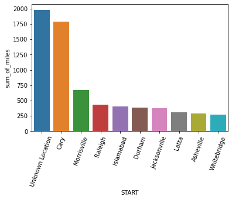

```python
k = df.groupby('START')['MILES'].sum().sort_values(ascending=False).head(10)
k = k.reset_index()  # series to df
k.columns = ['START' ,'sum_of_miles']
sns.barplot(data=k , x='START' , y='sum_of_miles');
plt.xticks(rotation=70);
```

# Destination - Farthest start-stop pair w.r.t miles covered ever

```python
# Perform on subset df to understand what will happen
dfTest = df.head(10).copy(deep=True)
dfTest
dfTest.groupby(['START','STOP'])['MILES'].sum().sort_values(ascending=False)
# Perform on original df
df.groupby(['START','STOP'])['MILES'].sum().sort_values(ascending=False).head(10)
```

```
START             STOP
Unknown Location  Unknown Location    1360.8
Morrisville       Cary                 395.7
Cary              Durham               390.0
                  Morrisville          380.0
Raleigh           Cary                 365.7
Cary              Raleigh              336.5
Durham            Cary                 334.4
Latta             Jacksonville         310.3
Islamabad         Unknown Location     267.0
Cary              Cary                 255.9
Name: MILES, dtype: float64
```

# Further, drop unknown location stations

```python
# Using start and stop conditions one by one
df2 = df[df['START']!= 'Unknown Location']
df2 = df2[df2['STOP']!= 'Unknown Location']
# OR
# Using both conditions together
# df2 = df[(df.START != 'Unknown Location') & (df.STOP != 'Unknown Location')]
df2.groupby(['START','STOP'])['MILES'].sum().sort_values(ascending=False).head(10)
```

```
START         STOP
Morrisville   Cary            395.7
Cary          Durham          390.0
              Morrisville     380.0
Raleigh       Cary            365.7
Cary          Raleigh         336.5
Durham        Cary            334.4
Latta         Jacksonville    310.3
Cary          Cary            255.9
Jacksonville  Kissimmee       201.0
Asheville     Mebane          195.9
Name: MILES, dtype: float64
```

# Notes

1. The start-stop pair with the max no. of miles covered ever is Morrisville-Cary followed closely by Cary-Durham and Cary-Morrisville

# Destination - most popular start-stop pair w.r.t. travel count

```python
# Perform on subset df to understand what will happen
dfTest1 = df2.head(10).copy(deep=True)
dfTest1
dfTest1.groupby(['START','STOP'])['MILES'].size().sort_values(ascending=False)
# Pefrom on real df
df2.groupby(['START','STOP'])['MILES'].size().sort_values(ascending=False).head(10)
```

```
START        STOP
Morrisville  Cary           75
Cary         Morrisville    67
             Cary           53
             Durham         36
Durham       Cary           32
Lahore       Lahore         27
Islamabad    Islamabad      25
Cary         Raleigh        23
Raleigh      Cary           21
Kar?chi      Kar?chi        20
Name: MILES, dtype: int64
```

# Notes

1. The most popular start-stop pair is Morrisville to Cary

# Time - convert format

```python
df.head()
df.dtypes
# Convert start and end date into datatime format
df['start_dt'] = df['START_DATE'].apply(lambda x : datetime.strptime(x, '%m/%d/%Y %H:%M'))
df['end_dt'] = df['END_DATE'].apply(lambda x : datetime.strptime(x, '%m/%d/%Y %H:%M'))
df.head()
# See how the dtype is different now
df.dtypes
```

```
START_DATE            object
END_DATE              object
CAT                   object
START                 object
STOP                  object
MILES                float64
PURPOSE               object
start_dt      datetime64[ns]
end_dt        datetime64[ns]
dtype: object
```

# Time - explore the inbuilt functionalities of datatime module

```python
# Create more cols from timestamps
df['start_day'] = df['start_dt'].dt.day
df['start_hour'] = df['start_dt'].dt.hour
df['start_month'] = df['start_dt'].dt.month
# Also day of week - days encoded as 0-6 (Mon=0, Tue =1, etc.)
df['d_of_wk'] = df['start_dt'].dt.dayofweek
df.head()
```

|  | START_DATE | END_DATE | CAT | START | STOP | MILES | PURPOSE | start_dt | end_dt | start_day | start_hour | start_month | d_of_wk |
| --- | --- | --- | --- | --- | --- | --- | --- | --- | --- | --- | --- | --- | --- |
| 0 | 1/1/2016 21:11 | 1/1/2016 21:17 | Business | Fort Pierce | Fort Pierce | 5.1 | Meal/Entertain | 2016-01-01 21:11:00 | 2016-01-01 21:17:00 | 1 | 21 | 1 | 4 |
| 1 | 1/2/2016 1:25 | 1/2/2016 1:37 | Business | Fort Pierce | Fort Pierce | 5.0 | NaN | 2016-01-02 01:25:00 | 2016-01-02 01:37:00 | 2 | 1 | 1 | 5 |
| 2 | 1/2/2016 20:25 | 1/2/2016 20:38 | Business | Fort Pierce | Fort Pierce | 4.8 | Errand/Supplies | 2016-01-02 20:25:00 | 2016-01-02 20:38:00 | 2 | 20 | 1 | 5 |
| 3 | 1/5/2016 17:31 | 1/5/2016 17:45 | Business | Fort Pierce | Fort Pierce | 4.7 | Meeting | 2016-01-05 17:31:00 | 2016-01-05 17:45:00 | 5 | 17 | 1 | 1 |
| 4 | 1/6/2016 14:42 | 1/6/2016 15:49 | Business | Fort Pierce | West Palm Beach | 63.7 | Customer Visit | 2016-01-06 14:42:00 | 2016-01-06 15:49:00 | 6 | 14 | 1 | 2 |

# Time - Convert week days from numeric form to text

```python
# Using a dict and `.apply()` function
labels = {0:'Mon',1:'Tue',2:'Wed',3:'Thur',4:'Fri',5:'Sat',6:'Sun'}
df['day_of_week'] = df['d_of_wk'].apply(lambda x: labels[x])
df.head()
# OR
# Using the builtin functions
df['day_of_week1'] = df['start_dt'].apply(lambda x : datetime.strftime(x,'%a'))
df.head()
```

|  | START_DATE | END_DATE | CAT | START | STOP | MILES | PURPOSE | start_dt | end_dt | start_day | start_hour | start_month | d_of_wk | day_of_week | day_of_week1 |
| --- | --- | --- | --- | --- | --- | --- | --- | --- | --- | --- | --- | --- | --- | --- | --- |
| 0 | 1/1/2016 21:11 | 1/1/2016 21:17 | Business | Fort Pierce | Fort Pierce | 5.1 | Meal/Entertain | 2016-01-01 21:11:00 | 2016-01-01 21:17:00 | 1 | 21 | 1 | 4 | Fri | Fri |
| 1 | 1/2/2016 1:25 | 1/2/2016 1:37 | Business | Fort Pierce | Fort Pierce | 5.0 | NaN | 2016-01-02 01:25:00 | 2016-01-02 01:37:00 | 2 | 1 | 1 | 5 | Sat | Sat |
| 2 | 1/2/2016 20:25 | 1/2/2016 20:38 | Business | Fort Pierce | Fort Pierce | 4.8 | Errand/Supplies | 2016-01-02 20:25:00 | 2016-01-02 20:38:00 | 2 | 20 | 1 | 5 | Sat | Sat |
| 3 | 1/5/2016 17:31 | 1/5/2016 17:45 | Business | Fort Pierce | Fort Pierce | 4.7 | Meeting | 2016-01-05 17:31:00 | 2016-01-05 17:45:00 | 5 | 17 | 1 | 1 | Tue | Tue |
| 4 | 1/6/2016 14:42 | 1/6/2016 15:49 | Business | Fort Pierce | West Palm Beach | 63.7 | Customer Visit | 2016-01-06 14:42:00 | 2016-01-06 15:49:00 | 6 | 14 | 1 | 2 | Wed | Wed |

# Time - Convert month from numeric form to text

```python
df['cal_month'] = df['start_month'].apply(lambda x: calendar.month_abbr[x])
df.head()
# OR
# Use the built in functions in datatime module
df['cal_month1'] =  df['start_dt'].apply(lambda x : datetime.strftime(x,'%b'))
df.head()
```

|  | START_DATE | END_DATE | CAT | START | STOP | MILES | PURPOSE | start_dt | end_dt | start_day | start_hour | start_month | d_of_wk | day_of_week | day_of_week1 | cal_month | cal_month1 |
| --- | --- | --- | --- | --- | --- | --- | --- | --- | --- | --- | --- | --- | --- | --- | --- | --- | --- |
| 0 | 1/1/2016 21:11 | 1/1/2016 21:17 | Business | Fort Pierce | Fort Pierce | 5.1 | Meal/Entertain | 2016-01-01 21:11:00 | 2016-01-01 21:17:00 | 1 | 21 | 1 | 4 | Fri | Fri | Jan | Jan |
| 1 | 1/2/2016 1:25 | 1/2/2016 1:37 | Business | Fort Pierce | Fort Pierce | 5.0 | NaN | 2016-01-02 01:25:00 | 2016-01-02 01:37:00 | 2 | 1 | 1 | 5 | Sat | Sat | Jan | Jan |
| 2 | 1/2/2016 20:25 | 1/2/2016 20:38 | Business | Fort Pierce | Fort Pierce | 4.8 | Errand/Supplies | 2016-01-02 20:25:00 | 2016-01-02 20:38:00 | 2 | 20 | 1 | 5 | Sat | Sat | Jan | Jan |
| 3 | 1/5/2016 17:31 | 1/5/2016 17:45 | Business | Fort Pierce | Fort Pierce | 4.7 | Meeting | 2016-01-05 17:31:00 | 2016-01-05 17:45:00 | 5 | 17 | 1 | 1 | Tue | Tue | Jan | Jan |
| 4 | 1/6/2016 14:42 | 1/6/2016 15:49 | Business | Fort Pierce | West Palm Beach | 63.7 | Customer Visit | 2016-01-06 14:42:00 | 2016-01-06 15:49:00 | 6 | 14 | 1 | 2 | Wed | Wed | Jan | Jan |

# Time - Monthly stats

```python
# Which month did he get most drives ?
df.groupby(['start_month']).size()
# What are the total miles run each month ?
# Peform on test subset to understand what will happen
dfTest2 = df.iloc[55:65]
dfTest2
dfTest2.groupby('cal_month')['MILES'].sum().sort_values(ascending = False)
# Perform on real df
df.groupby('cal_month')['MILES'].sum().sort_values(ascending = False)
# Similarly, find avg. dist. covered each month
df.groupby('cal_month').mean()['MILES'].sort_values(ascending = False)
```

```
cal_month
Apr    20.611111
Oct    17.075472
Sep    16.716667
Mar    14.990265
Jul    10.933929
Aug    10.041353
Jan     8.408197
Feb     7.897391
Jun     7.803704
May     7.424490
Dec     6.721233
Nov     6.695902
Name: MILES, dtype: float64
```

# Time - daily and hourly stats

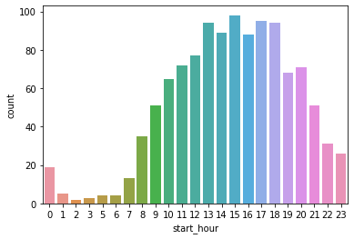

```python
#Which day did he get most drives  ?
df.groupby(['day_of_week']).size()
# Does he have a prefered time of start ?
dfTemp = df.groupby('start_hour').size()
dfTemp = dfTemp.reset_index()
dfTemp.columns = ['start_hour' ,'count']
sns.barplot(data= dfTemp , x ='start_hour' , y = 'count')
```

# Notes

# Time - duration stats

```python
# Duration of the trips
df['diff'] = (df['end_dt'] - df['start_dt'])
df.head()
# This creates a timedelta datatype
df.dtypes
# Convert to hour
df['diff_hr'] = df['diff'].astype('timedelta64[h]')
df['diff_hr'].describe()
# Further, convert to mins for easy inferencing
df['diff_mins'] = df['diff'].astype('timedelta64[m]')
df['diff_mins'].describe()
```

```
count    1155.000000
mean       23.243290
std        27.318277
min         0.000000
25%        10.000000
50%        16.000000
75%        27.500000
max       336.000000
Name: diff_mins, dtype: float64
```

# Notes

1. There seems to be something strange with the minumum time (mins) - it is 0 that implies start and stop time are same

# Investigating more Time

```python
# Which rows have same start and stop time
len(df[df['START_DATE'] == df['END_DATE']])
df[df['START_DATE'] == df['END_DATE']]
# OR
print(len(df))
# Remove such rows
# By simply negating the above condition
df3 = df[~(df['START_DATE'] == df['END_DATE'])]
# OR
# By using new condition with !=
# df3 = df[df.start_dt != df.end_dt]
print(len(df3))
```

```
1155
1151
```

# Time - trip speeds

```python
# Trip speed for each trip
df3.head()
df3['Duration_hours'] = df3['diff_mins']/60
df3.head()
df3['Speed'] = df3['MILES']/df3['Duration_hours']
df3.head()
df3['Speed'].describe()
# At this point see Notes below
# Top 5 small duration trips
df3.sort_values(by ='diff_mins', ascending = True).head(5)
df3 = df3[(df3.diff_mins > 5)]  # trips that lasted atleast 5 mins
# Top 5 small duration trips now
df3.sort_values(by ='diff_mins', ascending = True).head(5)
```

|  | START_DATE | END_DATE | CAT | START | STOP | MILES | PURPOSE | start_dt | end_dt | start_day | ... | d_of_wk | day_of_week | day_of_week1 | cal_month | cal_month1 | diff | diff_hr | diff_mins | Duration_hours | Speed |
| --- | --- | --- | --- | --- | --- | --- | --- | --- | --- | --- | --- | --- | --- | --- | --- | --- | --- | --- | --- | --- | --- |
| 0 | 1/1/2016 21:11 | 1/1/2016 21:17 | Business | Fort Pierce | Fort Pierce | 5.1 | Meal/Entertain | 2016-01-01 21:11:00 | 2016-01-01 21:17:00 | 1 | ... | 4 | Fri | Fri | Jan | Jan | 0 days 00:06:00 | 0.0 | 6.0 | 0.1 | 51.0 |
| 672 | 8/17/2016 16:54 | 8/17/2016 17:00 | Business | Unknown Location | Unknown Location | 5.3 | NaN | 2016-08-17 16:54:00 | 2016-08-17 17:00:00 | 17 | ... | 2 | Wed | Wed | Aug | Aug | 0 days 00:06:00 | 0.0 | 6.0 | 0.1 | 53.0 |
| 191 | 3/4/2016 19:02 | 3/4/2016 19:08 | Business | Cary | Morrisville | 1.9 | Temporary Site | 2016-03-04 19:02:00 | 2016-03-04 19:08:00 | 4 | ... | 4 | Fri | Fri | Mar | Mar | 0 days 00:06:00 | 0.0 | 6.0 | 0.1 | 19.0 |
| 189 | 3/4/2016 16:16 | 3/4/2016 16:22 | Business | Fayetteville Street | Depot Historic District | 0.8 | Errand/Supplies | 2016-03-04 16:16:00 | 2016-03-04 16:22:00 | 4 | ... | 4 | Fri | Fri | Mar | Mar | 0 days 00:06:00 | 0.0 | 6.0 | 0.1 | 8.0 |
| 179 | 3/3/2016 11:04 | 3/3/2016 11:10 | Business | Westpark Place | Whitebridge | 2.3 | Errand/Supplies | 2016-03-03 11:04:00 | 2016-03-03 11:10:00 | 3 | ... | 3 | Thur | Thu | Mar | Mar | 0 days 00:06:00 | 0.0 | 6.0 | 0.1 | 23.0 |

5 rows × 22 columns

# Notes

1. There are some really speedy cars as seen in `df3['Speed'].describe()`. One +ble reason is the small value of denominator i.e. time.
2. We should remove such records by taking a cutoff of time duration as 5 mins as trips with lesser duration make no sense. This cutoff can vary though.

# Category & Purpose

```python
df['CAT'].value_counts()
```

```
Business    1078
Personal      77
Name: CAT, dtype: int64
```

# Notes

1. Most trips are in the business category

# Purpose

```python
df['PURPOSE'].value_counts()
# Average distance traveled for each activity
df.groupby('PURPOSE').mean()['MILES'].sort_values(ascending = False)
```

```
PURPOSE
Commute            180.200000
Customer Visit      20.688119
Meeting             15.247594
Charity ($)         15.100000
Between Offices     10.944444
Temporary Site      10.474000
Meal/Entertain       5.698125
Airport/Travel       5.500000
Moving               4.550000
Errand/Supplies      3.968750
Name: MILES, dtype: float64
```

# Notes

1. Most trips are for meetings.

# Last questions - Question1

Question 1: How many miles were covered per category and purpose ?

```python
# Answer1:
# Per category
df.groupby('CAT').sum()['MILES'].sort_values(ascending = False)
# Per purpose
df.groupby('PURPOSE').sum()['MILES'].sort_values(ascending = False)
```

```
PURPOSE
Meeting            2851.3
Customer Visit     2089.5
Meal/Entertain      911.7
Temporary Site      523.7
Errand/Supplies     508.0
Between Offices     197.0
Commute             180.2
Moving               18.2
Airport/Travel       16.5
Charity ($)          15.1
Name: MILES, dtype: float64
```

# Last questions - Question2

Question 2: What is percentage of business miles vs personal?

```python
df4 = df.groupby('CAT').agg({'MILES':'sum'})
df4
df4.apply(lambda x: x/x.sum()*100).rename(columns = {'MILES':'% of Miles'})
```

| CAT | % of Miles |
| --- | --- |
| Business | 94.119479 |
| Personal | 5.880521 |

# Notes

1. @L:511 the `.agg()` function does the same as `.sum()`, but the former returns a df unlime the latter.

# Last questions - Question3

Question 3: How much time was spend for drives per category and purpose?

```python
# Answer3:
# Per category
df4= df.groupby('CAT').sum()['diff_mins'].sort_values(ascending = False)
df4.apply(lambda x: x/60)
# Per purpose
df5= df.groupby('PURPOSE').sum()['diff_mins'].sort_values(ascending = False)
df5.apply(lambda x: x/60)
print('Time elapased:', (pd.Timestamp.now()-start).total_seconds())
```

```
Time elapased: 4.709989
```